## Module 4

#### Hemi-module gene counts:

86 probesets in positive hemi-module.  
195 probesets in negative hemi-module.  
Note: While the mapping of probesets to genes is generally one-to-one, some probesets map to multiple genes and some do not map to any genes (i.e., the region of the genome they match is no longer considered genic).

#### Contrast SVE:

Signed variance explained (SVE) provides an indication of how similar a set of fold changes are to a gene module’s weight vector. An SVE value of 0.3, for example, indicates that 30% of the variance explained by the entire module set is accounted for the module in question. Shown here are the SVE values for this module accross a compendium of fold changes (contrasts). Extreme SVE values (e.g., > 0.05) indicate that those contrasts specifically induce (orange dots) or specifically repress (blue dots) this module. Examining the experimental conditions being compared in such contrasts (see tables below the figure) may provide insight into the gene module’s function.

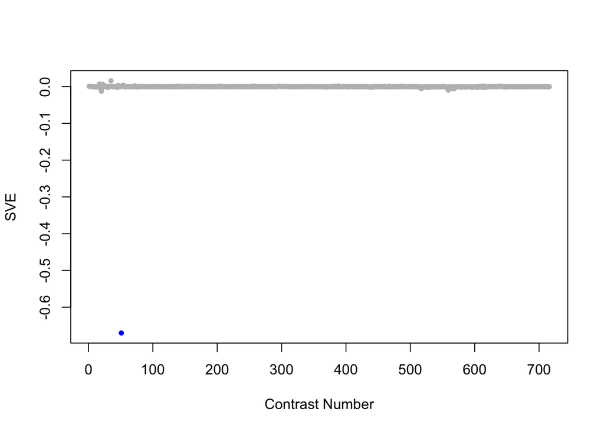

Positive SVE Contrasts:

|  | Contrast.Num | SVE | GEO.GSE | Cond.1 | Cond.2 | Mutation |
| --- | --- | --- | --- | --- | --- | --- |
| GSE9665.s3t3.vs.s0t3 | 35 | 0.02 | GSE9665 | mex-3 hlh-1 230 A | mex-3 230 A | hlh-1 |
| GSE9665.s1t1.vs.s0t1 | 17 | 0.01 | GSE9665 | mex-3 elt-1 143 A | mex-3 143 A | elt-1 |
| GSE9665.s1t2.vs.s0t2 | 22 | 0.01 | GSE9665 | mex-3 elt-1 186 A | mex-3 186 A | elt-1 |
| GSE9665.s2t2.vs.s0t2 | 23 | 0.00 | GSE9665 | mex-3 elt-3 186 A | mex-3 186 A | elt-3 |
| GSE9665.s9t2.vs.s9t1 | 54 | 0.00 | GSE9665 | mex-3 scrt-1 186 A | mex-3 scrt-1 143 A |  |

Negative SVE Contrasts:

|  | Contrast.Num | SVE | GEO.GSE | Cond.1 | Cond.2 | Mutation |
| --- | --- | --- | --- | --- | --- | --- |
| GSE9665.s8t4.vs.s8t1 | 51 | -0.67 | GSE9665 | mex-3 pal-1 101 A | mex-3 pal-1 143 A |  |
| GSE9665.s9t1.vs.s0t1 | 20 | -0.01 | GSE9665 | mex-3 scrt-1 143 A | mex-3 143 A | scrt-1 |
| GSE2180.s4t5.vs.s1t5 | 559 | -0.01 | GSE2180 | pp66-1 | 66-4 | pie-1(zu154);pal-1(RNAi) |
| GSE9665.s8t1.vs.s0t1 | 19 | -0.01 | GSE9665 | mex-3 pal-1 143 A | mex-3 143 A | pal-1 |
| GSE2180.s4t6.vs.s3t6 | 568 | -0.01 | GSE2180 | pp83-1 | p83-2 | pal-1(RNAi) |

#### Contrast SVE, Up-Regulated Genes Only:

Calculating SVE for up-regulated and down-regulated genes separately may be more informative in many cases than projecting the up- and down- gene sets together. This is due to the fact that the weight distribution of many modules is highly skewed, indicating that only one of the hemi-modules may be biologically meaningful (i.e., a set of genes are strongly correlated buy only a few genes (or none) are strongly anti-correlated to that set.)

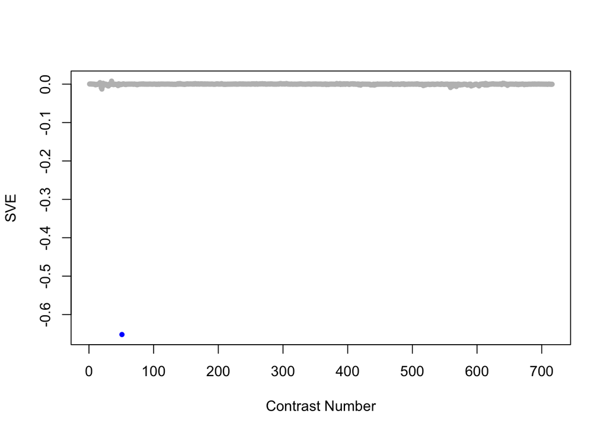

Positive SVE Contrasts:

|  | Contrast.Num | SVE | GEO.GSE | Cond.1 | Cond.2 | Mutation |
| --- | --- | --- | --- | --- | --- | --- |
| GSE9665.s3t3.vs.s0t3 | 35 | 0.01 | GSE9665 | mex-3 hlh-1 230 A | mex-3 230 A | hlh-1 |
| GSE9665.s1t1.vs.s0t1 | 17 | 0.00 | GSE9665 | mex-3 elt-1 143 A | mex-3 143 A | elt-1 |
| GSE18132.s2t2.vs.s2t1 | 640 | 0.00 | GSE18132 | Oga Fed L4, biological replicate 1 | Oga starved L1, biological replicate 1 |  |
| GSE9665.s1t2.vs.s0t2 | 22 | 0.00 | GSE9665 | mex-3 elt-1 186 A | mex-3 186 A | elt-1 |
| GSE18132.s0t2.vs.s0t1 | 642 | 0.00 | GSE18132 | WT Fed L4, biological rep1 | WT Starved L1, biological rep1 |  |

Negative SVE Contrasts:

|  | Contrast.Num | SVE | GEO.GSE | Cond.1 | Cond.2 | Mutation |
| --- | --- | --- | --- | --- | --- | --- |
| GSE9665.s8t4.vs.s8t1 | 51 | -0.65 | GSE9665 | mex-3 pal-1 101 A | mex-3 pal-1 143 A |  |
| GSE9665.s9t1.vs.s0t1 | 20 | -0.01 | GSE9665 | mex-3 scrt-1 143 A | mex-3 143 A | scrt-1 |
| GSE9665.s8t1.vs.s0t1 | 19 | -0.01 | GSE9665 | mex-3 pal-1 143 A | mex-3 143 A | pal-1 |
| GSE2180.s4t5.vs.s1t5 | 559 | -0.01 | GSE2180 | pp66-1 | 66-4 | pie-1(zu154);pal-1(RNAi) |
| GSE9665.s10t1.vs.s0t1 | 21 | -0.01 | GSE9665 | mex-3 tbx-8,9 143 A | mex-3 143 A | tbx-8,9 |

#### Contrast SVE, Down-Regulated Genes Only:

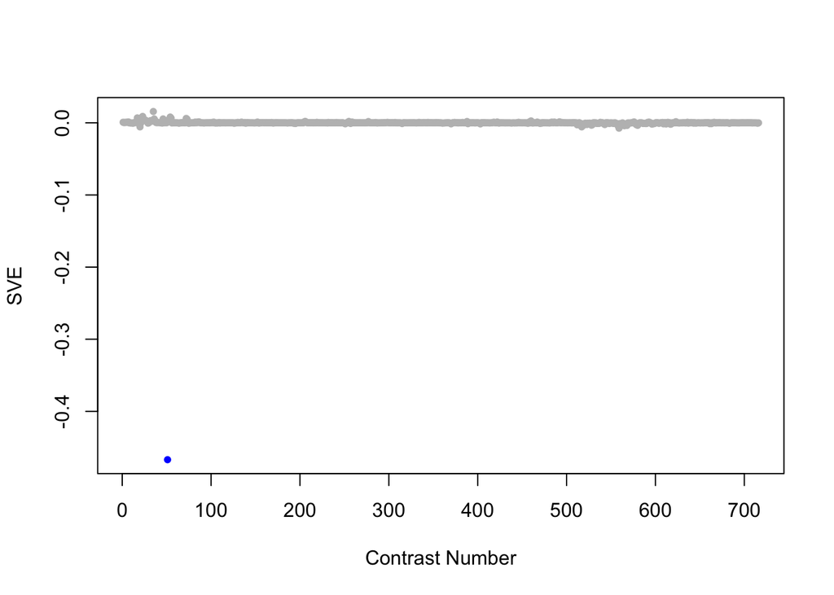

Positive SVE Contrasts:

|  | Contrast.Num | SVE | GEO.GSE | Cond.1 | Cond.2 | Mutation |
| --- | --- | --- | --- | --- | --- | --- |
| GSE9665.s3t3.vs.s0t3 | 35 | 0.02 | GSE9665 | mex-3 hlh-1 230 A | mex-3 230 A | hlh-1 |
| GSE9665.s2t2.vs.s0t2 | 23 | 0.01 | GSE9665 | mex-3 elt-3 186 A | mex-3 186 A | elt-3 |
| GSE9665.s9t2.vs.s9t1 | 54 | 0.01 | GSE9665 | mex-3 scrt-1 186 A | mex-3 scrt-1 143 A |  |
| GSE9665.s1t2.vs.s0t2 | 22 | 0.01 | GSE9665 | mex-3 elt-1 186 A | mex-3 186 A | elt-1 |
| GSE9665.s1t1.vs.s0t1 | 17 | 0.01 | GSE9665 | mex-3 elt-1 143 A | mex-3 143 A | elt-1 |

Negative SVE Contrasts:

|  | Contrast.Num | SVE | GEO.GSE | Cond.1 | Cond.2 | Mutation |
| --- | --- | --- | --- | --- | --- | --- |
| GSE9665.s8t4.vs.s8t1 | 51 | -0.47 | GSE9665 | mex-3 pal-1 101 A | mex-3 pal-1 143 A |  |
| GSE2180.s4t5.vs.s1t5 | 559 | -0.01 | GSE2180 | pp66-1 | 66-4 | pie-1(zu154);pal-1(RNAi) |
| GSE2180.s4t7.vs.s1t7 | 517 | -0.01 | GSE2180 | pp101-1 | 101G | pie-1(zu154);pal-1(RNAi) |
| GSE9665.s9t1.vs.s0t1 | 20 | -0.01 | GSE9665 | mex-3 scrt-1 143 A | mex-3 143 A | scrt-1 |
| GSE2180.s3t5.vs.s1t5 | 558 | -0.00 | GSE2180 | p66-1 | 66-4 | pie-1(zu154) |

#### GO Term Enrichment:

This analysis tests each hemi-module for enrichment of specific GO terms. Only gene-level annotations (e.g., as would be found on the gene’s page in Wormbase) are tested - the hiearchical structure of the GO ontology is not taken into account. Negative enrichment scores indicate fewer hemi-module genes than expected by random chance were assiciated with the GO term in question.

##### Significant GO terms: Positive hemi-module

No significant annotations.

##### Significant GO terms: Negative hemi-module

No significant annotations.

#### REACTOME Pathway Enrichment:

This analysis tests each hemi-module for enrichment of REACTOME pathways (n.b., the term ‘pathway’ is used very loosely by REACTOME, and can be something as small as a single biochemical reaction or even a macromolecular complex.) This analysis was performed using an old version of REACTOME, and they have since changed their ID scheme. Thus, the links to the REACTOME database are non-functional at present (but more info for a pathway can be found by searching for the pathway definition at http://www.reactome.org) Negative enrichment scores indicate fewer hemi-module genes than expected by random chance were associated with the pathway in question.

##### Significant REACTOME pathways: Positive hemi-module

No significant annotations.

##### Significant REACTOME pathways: Negative hemi-module

No significant annotations.

#### Tissue Enrichment:

This analysis tests each hemi-module for enrichment of genes associated with specific tissues. Negative enrichment scores indicate fewer hemi-module genes than expected by random chance were assiciated with the tissue in question.

##### Significant Enriched tissues: Positive hemi-module

No significant annotations.

##### Significant Enriched tissues: Negative hemi-module

No significant annotations.

#### Promoter Word Enrichment:

This analysis tests each hemi-module for enrichment of specific promoter words. The list of promoter words tested was generated by running the MobyDick algorithm (see PMID:10944202) on the full set of *C. elegans* 2 Kbp promoters. Negative enrichment scores indicate fewer hemi-module genes than expected by random chance were associated with the word in question.

##### Significant Promoter words: Positive hemi-module

| Word | RC | Enrichment.Score | Raw.p.value | Adj.p.value |
| --- | --- | --- | --- | --- |
| GAGCATC | GATGCTC | 8.33 | 4.73e-09 | 2.47e-05 |
| TCGATTTTC | GAAAATCGA | 7.88 | 1.33e-08 | 6.96e-05 |
| GAATATC | GATATTC | 7.78 | 1.65e-08 | 8.61e-05 |
| GACGA | TCGTC | 7.45 | 3.53e-08 | 1.84e-04 |
| TTAAAGGCGCAT | ATGCGCCTTTAA | 6.33 | 4.71e-07 | 2.46e-03 |
| AGAGTA | TACTCT | 6.24 | 5.78e-07 | 3.02e-03 |
| CTTCTTT | AAAGAAG | 6.21 | 6.19e-07 | 3.24e-03 |
| ATCAATA | TATTGAT | 6.15 | 7.10e-07 | 3.71e-03 |
| AATAAAACA | TGTTTTATT | 5.79 | 1.61e-06 | 8.38e-03 |
| GGCGTGG | CCACGCC | 5.65 | 2.22e-06 | 1.16e-02 |
| GCTCCTG | CAGGAGC | 5.62 | 2.40e-06 | 1.25e-02 |
| CTTCTT | AAGAAG | 5.59 | 2.57e-06 | 1.34e-02 |
| CGCTACG | CGTAGCG | 5.58 | 2.64e-06 | 1.38e-02 |
| CGATTTG | CAAATCG | 5.12 | 7.53e-06 | 3.92e-02 |
| TATTTTT | AAAAATA | 5.08 | 8.23e-06 | 4.29e-02 |
| GTGAAG | CTTCAC | 5.05 | 8.85e-06 | 4.61e-02 |
| GGACCAG | CTGGTCC | 4.95 | 1.12e-05 | 5.83e-02 |

##### Significant Promoter words: Negative hemi-module

| Word | RC | Enrichment.Score | Raw.p.value | Adj.p.value |
| --- | --- | --- | --- | --- |
| ATCGAT | ATCGAT | 8.80 | 1.57e-09 | 8.21e-06 |
| TGGGTCTCGT | ACGAGACCCA | 8.34 | 4.53e-09 | 2.37e-05 |
| TGCCGAA | TTCGGCA | 5.63 | 2.35e-06 | 1.23e-02 |
| TATCGAT | ATCGATA | 5.49 | 3.21e-06 | 1.68e-02 |
| CACCCCTG | CAGGGGTG | 5.39 | 4.11e-06 | 2.15e-02 |
| CTTAAC | GTTAAG | 5.25 | 5.69e-06 | 2.97e-02 |
| ATCGATT | AATCGAT | 5.15 | 7.02e-06 | 3.67e-02 |
| CGGTTGC | GCAACCG | 5.13 | 7.34e-06 | 3.83e-02 |
| CACTTTTT | AAAAAGTG | 5.10 | 7.91e-06 | 4.13e-02 |
| AGAGCGCA | TGCGCTCT | 5.02 | 9.46e-06 | 4.94e-02 |
| CTTTTTCTCT | AGAGAAAAAG | 4.93 | 1.16e-05 | 6.06e-02 |
| GAAGGG | CCCTTC | 4.90 | 1.25e-05 | 6.54e-02 |

#### 3’-UTR Word Enrichment:

This analysis tests each hemi-module for enrichment of specific 3’-UTR words. The list of words tested was generated by running the MobyDick algorithm (see PMID:10944202) on the full set of *C. elegans* 3’-UTR sequences. Negative enrichment scores indicate fewer hemi-module genes than expected by random chance were associated with the word in question.

##### Significant 3’-UTR words: Positive hemi-module

| Word | RC | Enrichment.Score | Raw.p.value | Adj.p.value |
| --- | --- | --- | --- | --- |
| TATTTATT | AATAAATA | 5.58 | 2.63e-06 | 2.53e-03 |
| TTCCTGT | ACAGGAA | 4.64 | 2.30e-05 | 2.21e-02 |
| TCCTGT | ACAGGA | 4.42 | 3.84e-05 | 3.69e-02 |

##### Significant 3’-UTR words: Negative hemi-module

No significant words.

#### Positive hemi-module genes

|  | affy_c_elegans | ensembl_gene_id | external_gene_name | module_weight | chromosome_name | strand | start_position | end_position |
| --- | --- | --- | --- | --- | --- | --- | --- | --- |
| 50 | 174427_s_at | WBGene00009440 | idhg-1 | 8.86 | III | 1 | 4567325 | 4571835 |
| 57 | 186575_s_at | WBGene00007413 | pro-2 | 8.32 | II | -1 | 10339692 | 10345112 |
| 76 | 174390_s_at | WBGene00012353 | W09C5.7 | 6.84 | I | 1 | 13654029 | 13658165 |
| 3 | 188761_s_at | WBGene00022456 | Y110A7A.6 | 6.73 | I | 1 | 5131288 | 5134105 |
| 31 | 194231_x_at | WBGene00007143 | B0334.3 | 6.35 | II | -1 | 11489605 | 11493021 |
| 78 | 175808_s_at | WBGene00000102 | akt-1 | 6.18 | V | 1 | 10248907 | 10252895 |
| 91 | 186930_s_at | WBGene00017606 | ets-6 | 6.10 | V | -1 | 7577529 | 7580520 |
| 64 | 188989_s_at | WBGene00011050 | agl-1 | 5.82 | II | -1 | 14350725 | 14357570 |
| 9 | 176010_at | WBGene00019678 | K12H4.3 | 5.75 | III | 1 | 8046034 | 8047611 |
| 75 | 188938_at | WBGene00017162 | ddx-23 | 5.41 | III | -1 | 5848839 | 5853269 |
| 44 | 189609_s_at | WBGene00000796 | crn-3 | 5.32 | II | 1 | 10588042 | 10592653 |
| 85 | 173324_s_at | WBGene00012126 | T28D6.6 | 5.30 | III | -1 | 11326654 | 11343108 |
| 83 | 193316_s_at | WBGene00013202 | Y54E5A.7 | 5.30 | I | 1 | 14711081 | 14715030 |
| 2 | 192772_at | WBGene00009264 | sac-1 | 5.28 | I | 1 | 9488488 | 9492623 |
| 79 | 189562_at | WBGene00000195 | arr-1 | 5.27 | X | 1 | 950782 | 954233 |
| 4 | 188760_at | WBGene00022456 | Y110A7A.6 | 5.22 | I | 1 | 5131288 | 5134105 |
| 81 | 173692_at | WBGene00017119 | E04A4.5 | 5.21 | IV | -1 | 4744350 | 4745492 |
| 61 | 174447_at | WBGene00008764 | dylt-1 | 5.17 | I | -1 | 7300062 | 7300913 |
| 23 | 174590_s_at | WBGene00004732 | sax-7 | 5.04 | IV | 1 | 8062669 | 8083962 |
| 41 | 178313_at | WBGene00086562 | T02G6.11 | 5.02 | I | 1 | 11820688 | 11823459 |
| 22 | 173865_at | WBGene00006351 | sur-5 | 4.99 | X | -1 | 7301357 | 7305570 |
| 8 | 193427_at | WBGene00000181 | ard-1 | 4.98 | IV | 1 | 11131279 | 11133785 |
| 54 | 174719_at | WBGene00001582 | gfi-2 | 4.87 | I | 1 | 9737823 | 9744122 |
| 67 | 173913_s_at | WBGene00014012 | riok-3 | 4.86 | III | -1 | 9802354 | 9805092 |
| 11 | 192378_at | WBGene00013880 | mppb-1 | 4.79 | IV | 1 | 9074673 | 9076571 |
| 17 | 183225_at | WBGene00021057 | W06B4.2 | 4.78 | II | 1 | 4468170 | 4471037 |
| 35 | 192874_at | WBGene00005648 | srp-7 | 4.74 | V | 1 | 8179131 | 8183442 |
| 30 | 185194_at | WBGene00017289 | F09E5.11 | 4.68 | II | -1 | 5357312 | 5358189 |
| 63 | 194129_s_at | WBGene00010665 | K08E3.5 | 4.57 | III | -1 | 13764064 | 13768092 |
| 51 | 177078_at | WBGene00010889 | M18.3 | 4.55 | IV | 1 | 12105858 | 12108397 |

[output cut: 63 more lines]

#### Negative hemi-module genes

|  | affy_c_elegans | ensembl_gene_id | external_gene_name | module_weight | chromosome_name | strand | start_position | end_position |
| --- | --- | --- | --- | --- | --- | --- | --- | --- |
| 138 | 181554_at | WBGene00017700 | F22D3.4 | -9.69 | II | -1 | 6924230 | 6925951 |
| 93 | 186721_at | WBGene00008348 | C56G7.3 | -8.59 | III | 1 | 3389921 | 3392524 |
| 7 | 184440_at | WBGene00012476 | Y18D10A.3 | -7.99 | I | -1 | 12810169 | 12815641 |
| 59 | 182711_at | WBGene00005965 | srx-74 | -7.80 | V | -1 | 4658949 | 4660327 |
| 32 | 180825_at | WBGene00012513 | Y26E6A.2 | -7.79 | X | -1 | 13910937 | 13912980 |
| 192 | 183184_at | WBGene00015586 | C08A9.6 | -7.77 | X | -1 | 17094283 | 17096537 |
| 169 | 180772_at | WBGene00011542 | fbxa-104 | -7.62 | V | -1 | 15421673 | 15423658 |
| 168 | 184625_at | WBGene00019044 | F58E1.13 | -7.34 | II | -1 | 1694815 | 1695827 |
| 97 | 179100_at | WBGene00012038 | T26E3.5 | -7.30 | I | -1 | 12662938 | 12663833 |
| 157 | 184382_at | WBGene00021723 | bath-8 | -7.28 | II | 1 | 3380288 | 3381403 |
| 10 | 177197_at | WBGene00005532 | sri-20 | -7.07 | V | 1 | 10368556 | 10369868 |
| 185 | 178827_at | WBGene00013935 | ZK218.1 | -6.99 | V | 1 | 17092570 | 17093401 |
| 188 | 187867_at | WBGene00004802 | sir-2.3 | -6.78 | X | 1 | 13332016 | 13333689 |
| 20 | 171788_x_at | WBGene00000832 | ctn-1 | -6.76 | I | 1 | 2606754 | 2617361 |
| 11 | 192438_at | WBGene00010180 | nhr-192 | -6.76 | V | -1 | 10069369 | 10070641 |
| 120 | 191745_at | WBGene00008723 | F12F6.8 | -6.72 | IV | -1 | 11554491 | 11558428 |
| 134 | 182216_at | WBGene00020835 | T27A1.3 | -6.61 | II | 1 | 535578 | 538309 |
| 107 | 183093_at | WBGene00018180 | srsx-22 | -6.58 | V | 1 | 8351671 | 8353085 |
| 47 | 182147_at | WBGene00011864 | T20F10.2 | -6.58 | I | 1 | 10298215 | 10300587 |
| 73 | 183772_at | WBGene00009063 | F22G12.3 | -6.57 | I | 1 | 13152575 | 13153706 |
| 23 | 178680_at | WBGene00010859 | M04C9.4 | -6.52 | I | -1 | 9355072 | 9357079 |
| 129 | 176204_s_at | WBGene00021668 | Y48G1BM.2 | -6.46 | I | 1 | 240491 | 245414 |
| 119 | 178358_at | WBGene00009437 | F35G2.3 | -6.45 | IV | 1 | 12209708 | 12210737 |
| 42 | 171830_x_at | WBGene00013002 | Y48E1B.3 | -6.42 | II | -1 | 13547249 | 13567999 |
| 200 | 179085_at | WBGene00010099 | fbxb-117 | -6.35 | V | 1 | 19282614 | 19284594 |
| 57 | 184765_at | WBGene00018246 | clec-148 | -6.32 | III | -1 | 174609 | 175833 |
| 179 | 186594_at | WBGene00018447 | irld-9 | -6.32 | II | -1 | 1736866 | 1738944 |
| 40 | 190433_s_at | WBGene00007464 | C08H9.3 | -6.27 | II | -1 | 9882728 | 9886442 |
| 121 | 178470_s_at | WBGene00012096 | T27E9.6 | -6.20 | III | -1 | 13475406 | 13476107 |
| 130 | 186563_at | WBGene00011963 | T23G5.3 | -6.03 | III | -1 | 9229235 | 9231210 |

[output cut: 178 more lines]